# 232_assignment_2

Claire Madden and Lydia Bleifuss

4/9/2020

```r
# might want to consider how to do this for any climate data that might be input, in case the headers are not the same
# should just rename all the headers ?
# add error checking for column headers that are required to run the function
# check row length of columns to make sure they match

# use sapply to say (for each year do this thing)

# pick one of the five parameters to vary - it doesn't matter which
```

Assignment Details:

Lobell et al (2006) present several empirical models that related yield of different California crops to climate variables.

1. Implement a model of almond yield anomaly (difference from average) in R based on this paper; You will be graded both on the “correctness” of the implementation and on “style”. **Make sure you add some error checking.** Use coefficients in the paper as default values, but make sure you can vary them.
- see .R doc, still need to add error checking
2. Have the function return almond yield anomaly for each year, and max and minimum yields over a time series of multiple year inputs

```r
# use function to return list of yield anomolies and the max and min anomoly over the time series

source("../R/yield_anom.R")
yield_anom_list <- yield_anom(clim_data = clim_data)
```

3. With the climate data provided (clim.txt), *use your model* to estimate how almond yield anomalies for each year in the record - graph the results.

```r
# first need to change the function output to a dataframe so we can graph it

yield_anom_df <- data.frame(yield_anom_list[1]) %>%
  mutate(scenario = "baseline")
```

[figure not shown]

```r
yield_anom_1 <- ggplot(data = yield_anom_df, aes(x = year, y = y_anom)) +
  geom_col(fill = "peru", width = 0.5, show.legend = FALSE, alpha = 0.8) +
  theme_classic() +
   ggtitle("Yield Anom (1989 - 2010)\n") +
  xlab("\nYear") +
  ylab("Yield (tons/acre)") +
  theme(plot.title = element_text(size=12)) +
  theme(plot.title = element_text(hjust = 0.5)) +
  scale_x_continuous(expand = c(0,0), limits = c(1989,2010)) +
  theme(axis.text.x = element_text(angle = 45, hjust = 1)) +
  scale_y_continuous(expand = c(0,0)) +
    labs(caption = "\nFigure 1. Caption.")

yield_anom_1
```

4. Use model to estimate the mean annual yield anomaly if the last 20 years had been 2C warmer

```r
source("../R/yield_anom_2c.R")

yield_anom_list2 <- yield_anom_2c(clim_data = clim_data)

yield_anom_df2 <- data.frame(yield_anom_list2[1]) %>%
  mutate(scenario = "2 degrees warmer") %>%
  rename(y_anom = y_anom_2c)


mean_anom <- mean(yield_anom_df$y_anom)
mean_anom_2c <- mean(yield_anom_df2$y_anom)
```

The mean annual yield anomaly under the baseline conditions = -0.3581853. If the last 20 years had been 2 degrees warmer, the mean annual yield anomaly = -0.5674838

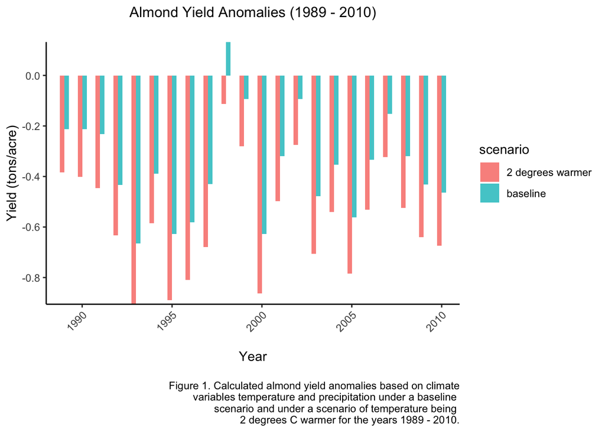

```r
#combine yield anom for baseline and 2deg warmer into single df
yield_anom_merge <- rbind(yield_anom_df, yield_anom_df2)

# graph the results of both on single column graph
yield_anom_2 <- ggplot(data = yield_anom_merge, aes(x = year, y = y_anom))+
  geom_col(aes(fill = scenario),position = "dodge", width = 0.5, alpha = 0.8) +
  theme_classic() +
   ggtitle("Almond Yield Anomalies (1989 - 2010)\n") +
  xlab("\nYear") +
  ylab("Yield (tons/acre)") +
  theme(plot.title = element_text(size=12)) +
  theme(plot.title = element_text(hjust = 0.5)) +
  scale_x_continuous(expand = c(0,0), limits = c(1988,2011)) +
  theme(axis.text.x = element_text(angle = 45, hjust = 1)) +
  scale_y_continuous(expand = c(0,0)) +
  labs(caption = "\nFigure 1. Calculated almond yield anomalies based on climate\n variables temperature and precipitation under a baseline \nscenario and under a scenario of temperature being \n2 degrees C warmer for the years 1989 - 2010.")

yield_anom_2
```

5. Vary one of the parameter by sampling from a normal distribution with mean the value from Lobell et al., (2006) and standard deviation 10% of the mean - create a box plot of mean annual yield anomaly for baseline and 2C climate (where boxes show variation due to uncertanty in the parameter)

```r
# trying to have a range of tn2 for each year and apply that in functions, not working for me
#
# param_tn2 = rnorm(10, -0.0046, sd = 0.1)
#
#
# for(i in 1:length(param_tn2)){
#
#   var_anom <- yield_anom(clim_data=clim_data, tn2 = param_tn2[i])
#   var_mean <- mean(data.frame((var_anom[[1]])$y_anom))
#
#   var_anom_2c <- yield_anom_2c(clim_data=clim_data, tn2 = param_tn2[i])
#   var_2c_mean <- mean(data.frame((var_anom_2c[[1]])$y_anom_2c))
#
# }
```

```r
param = rnorm(22, -0.0046, sd=0.1)
param_df = as.data.frame(param)


for(i in 1:length(param)){

  tn2_anom <- yield_anom(clim_data=clim_data, tn2 = param[i])

  tn2_anom_2c <- yield_anom_2c(clim_data=clim_data, tn2 = param[i])

}
```

```r
tn2_anom_df1 <- data.frame(tn2_anom[1]) %>%
  mutate(scenario = "baseline")

tn2_anom_df2 <- data.frame(tn2_anom_2c[1]) %>%
  mutate(scenario = "2 degrees warmer") %>%
  rename(y_anom = y_anom_2c)

tn2_anom_merge <- rbind(tn2_anom_df1, tn2_anom_df2)
```

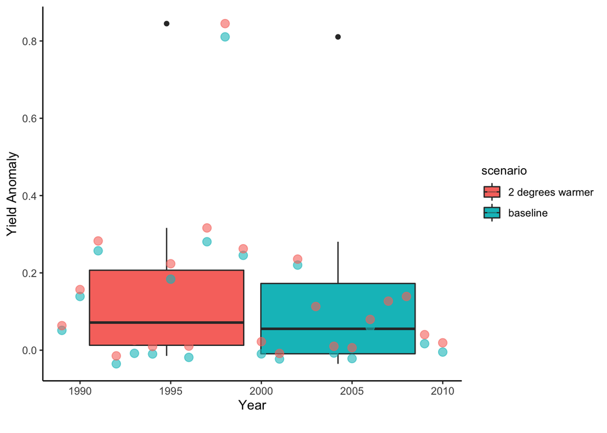

```r
tn2_box <- ggplot(data = tn2_anom_merge, aes(y = y_anom, x = year, fill = scenario)) +
  geom_boxplot(aes(fill = scenario)) +
  geom_point(aes(color = scenario), size = 3, alpha = 0.6) +
  theme_classic() +
  xlab("Year\n") +
  ylab("Yield Anomaly") +
  theme(plot.title = element_text(size=10)) +
theme(plot.title = element_text(hjust = 0.5))+
 theme(legend.title = element_text(size=10), legend.position = "right")

tn2_box
```

Keep your function as a *.R file - and use an Rmarkdown document to show how you used your function to answer 3-5

Turn both the *.R file and the Rmarkdown document on guachospace

Extra Credit - write a function that would make it easy to model ANY of the crops in Lobell

Turn in on Gauchospace - the .R function, that you used in the project (and to create the help pages) and a text file that gives your answers to questions